# TS_HW2_Liang_Gong

The ARIMA(0,2,1) model in terms of the backshift operator B can be written as: (1-B)^2 yt = ϵt+θ1*ϵt-1

Substituting the coefficient θ1 = −0.8963: (1-B)^2 yt = ϵt-0.8963*ϵt-1

ϵt-1 can be expressed in terms of ϵt using the backshift operator B ϵt-1=B*ϵt

Using this, the ARIMA(0,2,1) model can be rewritten as: (1-B)^2 yt = (1-0.8963B)ϵt

```r
report(fit)
```

```
## Series: Passengers
## Model: ARIMA(0,2,1)
##
## Coefficients:
##           ma1
##       -0.8963
## s.e.   0.0594
##
## sigma^2 estimated as 4.308:  log likelihood=-97.02
## AIC=198.04   AICc=198.32   BIC=201.65
```

**c. Plot forecasts from an ARIMA(0,1,0) model with drift and compare these to part a.**

In the ARIMA(0,1,0) model, drift refers to a constant term added to the differenced series, representing a linear trend in the original data. It accounts for a consistent upward or downward movement over time, even after differencing.

Based on the statistical metrics, the ARIMA(0,2,1) model generally outperforms the ARIMA(0,1,0). It offers a slightly better fit to the data, as indicated by a higher log-likelihood, and has lower AIC, AICc, and BIC valuee. ARIMA(0,2,1) is the more suitable model for analyzing the time-series data.

sigma2 measures the variance of the residuals (observed value - fitted value) after fitting the model.

```r
# Fit the ARIMA(0,1,0) model with drift
fit_arima_drift <- aus_airpassengers %>%
  model(ARIMA(Passengers ~ 1 + pdq(0,1,0)))

# View the model summary
report(fit_arima_drift)
```

```
## Series: Passengers
## Model: ARIMA(0,1,0) w/ drift
##
## Coefficients:
##       constant
##         1.4191
## s.e.    0.3014
##
## sigma^2 estimated as 4.271:  log likelihood=-98.16
## AIC=200.31   AICc=200.59   BIC=203.97
```

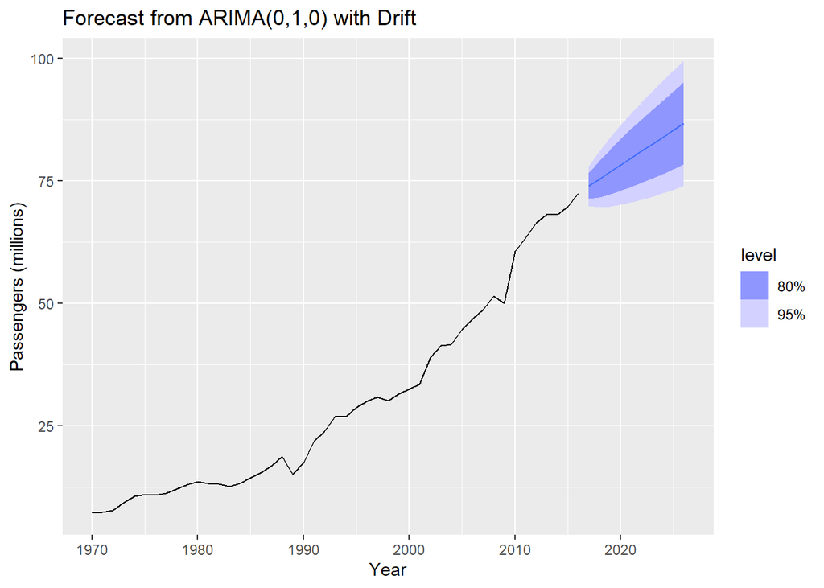

```r
# Forecast for the next 10 periods using ARIMA(0,1,0) with drift
fc_arima_drift <- fit_arima_drift %>%
  forecast(h = 10)

# Plot the forecast
fc_arima_drift %>%
  autoplot(aus_airpassengers) +
  ggtitle("Forecast from ARIMA(0,1,0) with Drift") +
  xlab("Year") +
  ylab("Passengers (millions)")
```

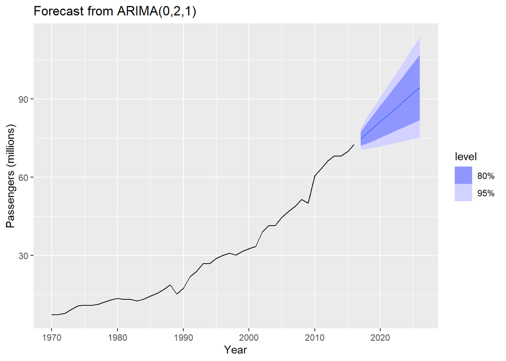

```r
# Plot the forecast with ARIMA(0,2,1)
fc %>%
  autoplot(aus_airpassengers) +
  ggtitle("Forecast from ARIMA(0,2,1)") +
  xlab("Year") +
  ylab("Passengers (millions)")
```

```r
# ARIMA(0,2,1) from parts a
glance(fit)
```

```
## # A tibble: 1 × 8
##   .model            sigma2 log_lik   AIC  AICc   BIC ar_roots  ma_roots
##   <chr>              <dbl>   <dbl> <dbl> <dbl> <dbl> <list>    <list>
## 1 ARIMA(Passengers)   4.31   -97.0  198.  198.  202. <cpl [0]> <cpl [1]>
```

```r
# ARIMA(0,1,0) from parts c
glance(fit_arima_drift)
```

```
## # A tibble: 1 × 8
##   .model                      sigma2 log_lik   AIC  AICc   BIC ar_roots ma_roots
##   <chr>                        <dbl>   <dbl> <dbl> <dbl> <dbl> <list>   <list>
## 1 ARIMA(Passengers ~ 1 + pdq…   4.27   -98.2  200.  201.  204. <cpl>    <cpl>
```

**d. Plot forecasts from an ARIMA(2,1,2) model with drift and compare these to parts a and c. Remove the constant and see what happens.**

The ARIMA(2,1,2) model with drift provides a slightly better fit, shown by lower residual variance and higher log-likelihood. However, its significantly higher AIC, AICc, and BIC compared to the simpler ARIMA(0,2,1)/ARIMA(0,1,0) model suggest that the added complexity is not justified.

The ARIMA(2,1,2) model without drift failed to fit because the AR part is non-stationary, meaning the parameters do not satisfy the stationarity conditions. As a result, the model could not be estimated, and no valid results were produced.

model(arima212 = ARIMA(Passengers ~ 0 + pdq(2,1,2))): forcing no drift in the differenced data implies that the original data is modeled without a linear trend. It indirectly enforces the AR part of the original data to be stationary, as it removes the possibility of a trend in the model.

```r
aus_fit_212_drift <- aus_airpassengers %>%
  model(ARIMA(Passengers ~ 1 + pdq(2,1,2)))

report(aus_fit_212_drift)
```

```
## Series: Passengers
## Model: ARIMA(2,1,2) w/ drift
##
## Coefficients:
##           ar1      ar2     ma1     ma2  constant
##       -0.5518  -0.7327  0.5895  1.0000    3.2216
## s.e.   0.1684   0.1224  0.0916  0.1008    0.7224
##
## sigma^2 estimated as 4.031:  log likelihood=-96.23
## AIC=204.46   AICc=206.61   BIC=215.43
```

```r
glance(aus_fit_212_drift)
```

```
## # A tibble: 1 × 8
##   .model                      sigma2 log_lik   AIC  AICc   BIC ar_roots ma_roots
##   <chr>                        <dbl>   <dbl> <dbl> <dbl> <dbl> <list>   <list>
## 1 ARIMA(Passengers ~ 1 + pdq…   4.03   -96.2  204.  207.  215. <cpl>    <cpl>
```

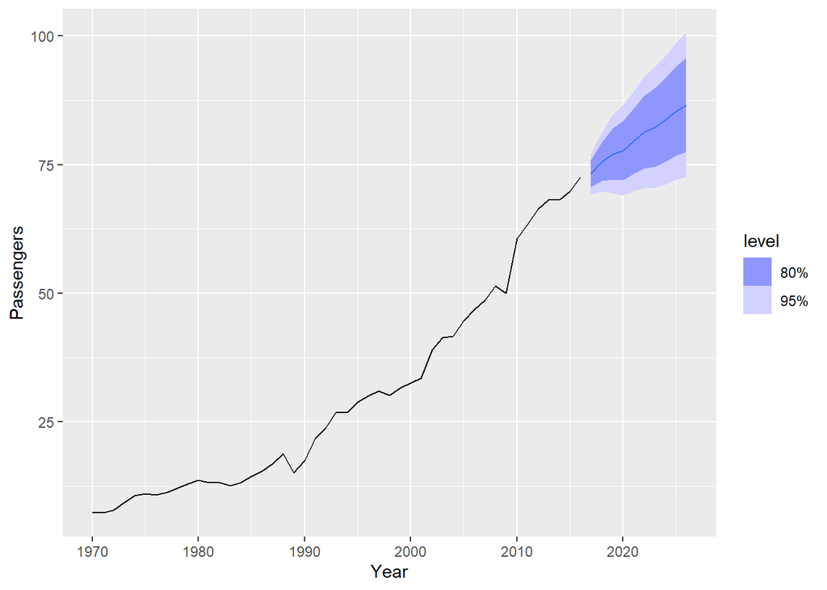

```r
aus_fit_212_drift %>% forecast(h=10) %>%
  autoplot(aus_airpassengers)
```

```r
aus_fit_212_nodrift <- aus_airpassengers %>%
  model(arima212 = ARIMA(Passengers ~ 0 + pdq(2,1,2)))
report(aus_fit_212_nodrift)
```

```
## Series: Passengers
## Model: NULL model
## NULL model
```

**e. Plot forecasts from an ARIMA(0,2,1) model with a constant. What happens?**

a constant in an ARIMA model with d=2 translates to a quadratic trend in the original data. By default, ARIMA excludes the constant when d≥1 unless explicitly specified.

Observations from the forecast graph (ARIMA(0,2,1) model with a constant) reveal a noticeably steeper trend line, with forecasted values significantly higher than those in earlier models

Comparing the results of the two ARIMA models:

### Summary:

1. **ARIMA(Passengers ~ 1 + pdq(0,2,1)):** Includes a constant term, allowing a quadratic trend in the original data.
   - $\sigma^2 = 3.855$ (lower residual variance)
   - Log-likelihood = $-95.10$ (better fit)
   - AIC = 196.21, AICc = 196.79, BIC = 201.63 (better values, indicating improved model fit)
2. **ARIMA(Passengers ~ 0 + pdq(0,2,1)):** No constant term, preventing a quadratic trend.
   - $\sigma^2 = 4.308$ (higher residual variance)
   - Log-likelihood = $-97.02$ (worse fit)
   - AIC = 198.04, AICc = 198.32, BIC = 201.65 (worse values)

### Conclusion:

While the model with the constant provides a better statistical fit, the added complexity (quadratic trend) should be justified by domain knowledge. Otherwise, the simpler model without the constant is preferable to avoid overfitting or unrealistic trends.

```r
aus_fit_021_drift <- aus_airpassengers %>%
  model(ARIMA(Passengers ~ 1 + pdq(0,2,1)))
report(aus_fit_021_drift)
```

```
## Series: Passengers
## Model: ARIMA(0,2,1) w/ poly
##
## Coefficients:
##           ma1  constant
##       -1.0000    0.0571
## s.e.   0.0585    0.0213
##
## sigma^2 estimated as 3.855:  log likelihood=-95.1
## AIC=196.21   AICc=196.79   BIC=201.63
```

```r
glance(aus_fit_021_drift)
```

```
## # A tibble: 1 × 8
##   .model                      sigma2 log_lik   AIC  AICc   BIC ar_roots ma_roots
##   <chr>                        <dbl>   <dbl> <dbl> <dbl> <dbl> <list>   <list>
## 1 ARIMA(Passengers ~ 1 + pdq…   3.85   -95.1  196.  197.  202. <cpl>    <cpl>
```

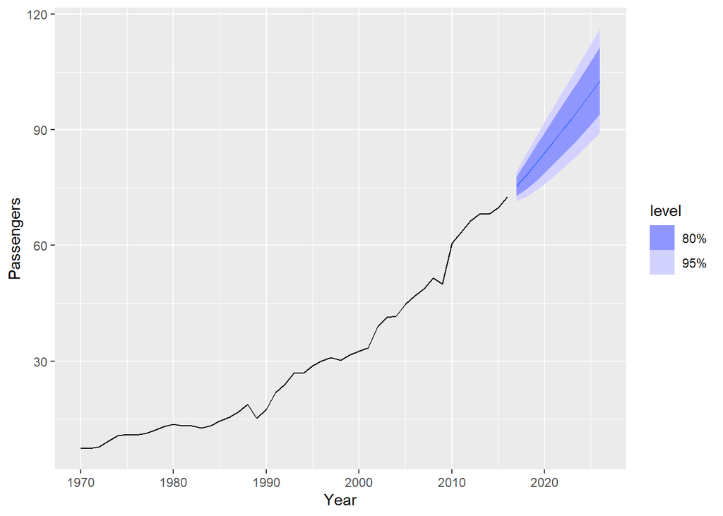

```r
aus_fit_021_drift %>% forecast(h=10) %>%
  autoplot(aus_airpassengers)
```

**9.15 Consider the number of Snowshoe Hare furs traded by the Hudson Bay Company between 1845 and 1935 (data set pelt).**

**a. Produce a time plot of the time series.**

```r
glimpse(pelt)
```

```
## Rows: 91
## Columns: 3
## $ Year <dbl> 1845, 1846, 1847, 1848, 1849, 1850, 1851, 1852, 1853, 1854, 1855,…
## $ Hare <dbl> 19580, 19600, 19610, 11990, 28040, 58000, 74600, 75090, 88480, 61…
## $ Lynx <dbl> 30090, 45150, 49150, 39520, 21230, 8420, 5560, 5080, 10170, 19600…
```

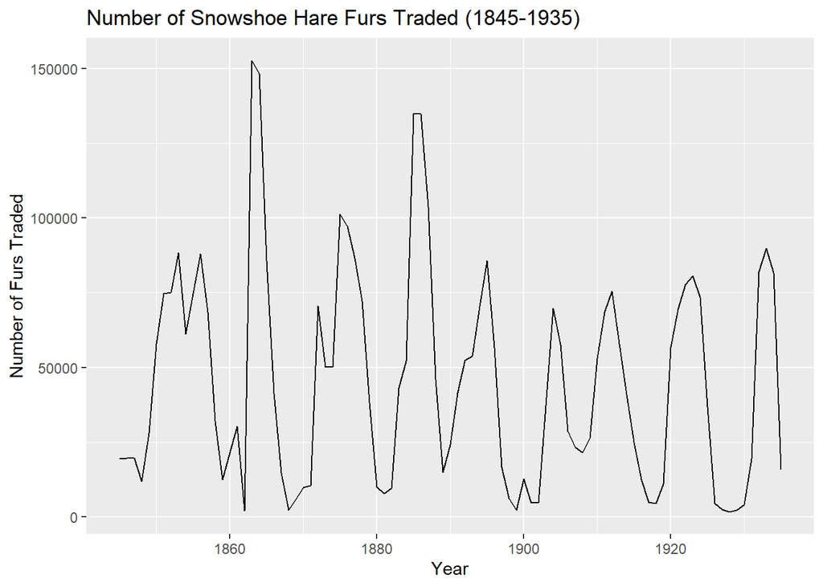

```r
# Produce the time plot
autoplot(pelt, Hare) +
  ggtitle("Number of Snowshoe Hare Furs Traded (1845-1935)") +
  xlab("Year") +
  ylab("Number of Furs Traded")
```

**b. Assume you decide to fit the following model: yt = c + ϕ1yt−1 + ϕ2yt−2 + ϕ3yt−3 + ϕ4yt−4 + εt where εt is a white noise series. What sort of ARIMA model is this (i.e., what are p, d, and q)?**

This is an **ARIMA(4,0,0)** model.

$$y_t = c + \phi_1 y_{t-1} + \phi_2 y_{t-2} + \phi_3 y_{t-3} + \phi_4
y_{t-4} + \epsilon_t$$

Identifying ARIMA components:

1. $p$ (AR order): The model includes 4 lagged terms of $y_t$ ($y_{t-1}, y_{t-2}, y_{t-3}, y_{t-4}$), so $p = 4$.
2. $d$ (Differencing order): There is no differencing term (no $(1-B)^d$ operator), so $d = 0$.
3. $q$ (MA order): There are no lagged error terms ($\epsilon_{t-1}, \epsilon_{t-2},$ etc.), so $q = 0$.

**c. By examining the ACF and PACF of the data, explain why this model is appropriate.**

The **partial autocorrelation function (PACF)** plot shows significant spikes at lags 1 through 4, followed by a sharp cutoff. This pattern indicates that an **AR model of order 4 (**$p=4$) is appropriate.

**No differencing (**$d = 0$): - The time plot shows the data fluctuates around a consistent mean and does not exhibit a clear trend (upward or downward) that would require differencing to achieve stationarity. - The ACF plot does not display a pattern of slow decay, which would indicate non-stationarity and require differencing.

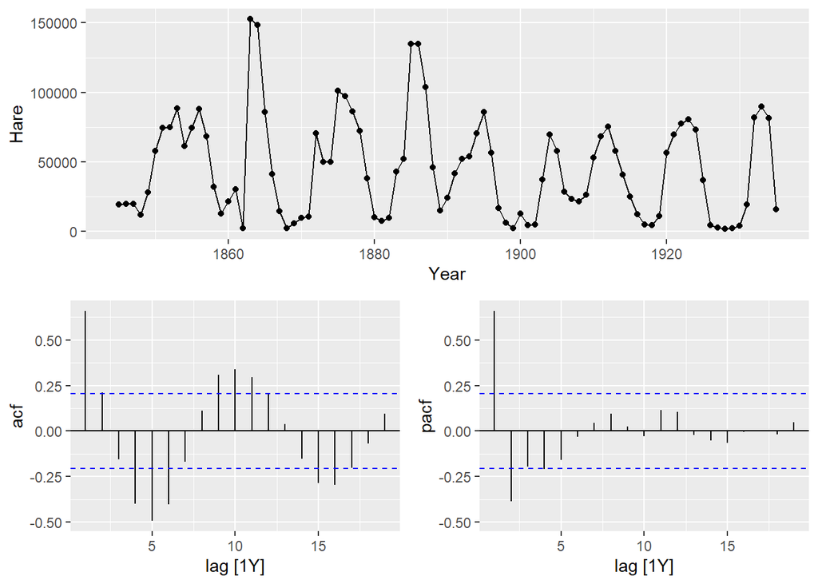

```r
gg_tsdisplay(pelt, y = Hare, plot_type='partial')
```

**d. Without using the forecast() function, calculate forecasts for the next three years (1936–1939).**

```r
view(pelt)
```

```r
C = 30993

y_1931 = 19520
y_1932 = 82110
y_1933 = 89760
y_1934 = 81660
y_1935 = 15760

pred_1936 = C + 0.82*y_1935 - 0.29*y_1934 - 0.01*y_1933 - 0.22*y_1932
pred_1937 = C + 0.82*pred_1936 - 0.29*y_1935 - 0.01*y_1934 - 0.22*y_1933
pred_1938 = C + 0.82*pred_1937 - 0.29*pred_1936 - 0.01*y_1935 - 0.22*y_1934
pred_1939 = C + 0.82*pred_1938 - 0.29*pred_1937 - 0.01*pred_1936 - 0.22*y_1935

data.frame(pred_1936, pred_1937, pred_1938, pred_1939)
```

```
##   pred_1936 pred_1937 pred_1938 pred_1939
## 1      1273   6902.66  18161.21  40403.49
```

**e. Now fit the model in R and obtain the forecasts using forecast(). How are they different from yours? Why?**

The results of the ARIMA(4,0,0) drew from R are somewhat different with the manually calculated results. This is due to precision of coefficients, for example, ϕ3 = -0.01 in the manual calculations but in the actual model it is -0.0057.

```r
pelt %>%
  model(ARIMA(Hare ~ pdq(4,0,0))) %>%
  forecast(h=4)
```

```
## # A fable: 4 x 4 [1Y]
## # Key:     .model [1]
##   .model  Year              Hare
##   <chr>  <dbl>            <dist>
## 1 ARIMA…  1936  N(2052, 5.9e+08)
## 2 ARIMA…  1937  N(8223, 9.8e+08)
## 3 ARIMA…  1938 N(19388, 1.1e+09)
## 4 ARIMA…  1939 N(41128, 1.1e+09)
## # ℹ 1 more variable: .mean <dbl>
```

```r
# Fit the ARIMA model
fit <- pelt %>%
  model(ARIMA(Hare ~ pdq(4,0,0)))

# View the model parameters
report(fit)
```

```
## Series: Hare
## Model: ARIMA(4,0,0) w/ mean
##
## Coefficients:
##          ar1      ar2      ar3      ar4  constant
##       0.8219  -0.2891  -0.0057  -0.2165  30993.12
## s.e.  0.1037   0.1367   0.1358   0.1036   2497.78
##
## sigma^2 estimated as 587643879:  log likelihood=-1045.91
## AIC=2103.82   AICc=2104.82   BIC=2118.89
```